# C2 Input Verification

Validate C1→C2 handoff: classified chunks and motivation-filtered input

Authors

Affiliation

Esteban Degetau

World Bank

Agustín Samano

World Bank

Published

May 30, 2026

Keywords

Fiscal policy, AI for social science

## Overview

Before building the C2 codebook or running evaluation, this notebook verifies the C1→C2 data handoff. Two targets are checked:

- `c1_classified_chunks`: C1 S2 classifications merged with chunk text and ground truth labels from `aligned_data`
- `c2_input_data`: Filtered to `pred_label == "FISCAL_MEASURE"` and `discusses_motivation == TRUE`

Eight tests check coverage, label completeness, text joins, C1 output fields, filter correctness, post-filter act coverage, class balance, and token distribution.

```r
pacman::p_load(targets, tidyverse, gt, here, scales)

here::i_am("notebooks/verify_c2_inputs.qmd")
tar_config_set(store = here("_targets"))
source(here("R/gt_theme.R"))
```

```r
c1_classified <- tar_read(c1_classified_chunks)
c2_input      <- tar_read(c2_input_data)
aligned_data  <- tar_read(aligned_data)
```

```r
test_results <- tibble(
  test_id = integer(),
  test_name = character(),
  result = character(),
  status = character()
)

add_result <- function(id, name, result, status) {
  test_results <<- bind_rows(
    test_results,
    tibble(test_id = id, test_name = name, result = result, status = status)
  )
}
```

## Part A: `c1_classified_chunks` (Precursor)

### Test 1: Act Coverage

Every act in `aligned_data` should appear in `c1_classified_chunks`.

```r
aligned_acts <- sort(unique(aligned_data$act_name))
classified_acts <- sort(unique(c1_classified$act_name))

missing <- setdiff(aligned_acts, classified_acts)
extra <- setdiff(classified_acts, aligned_acts)
coverage_ok <- length(missing) == 0 && length(extra) == 0

add_result(
  1, "Act coverage",
  sprintf("%d/%d acts present", length(classified_acts), length(aligned_acts)),
  if (coverage_ok) "PASS" else "FAIL"
)
```

```r
if (length(missing) > 0) {
  cat("\n\n**Acts in aligned_data but missing from c1_classified_chunks:**\n\n")
  for (act in missing) cat(sprintf("- %s\n", act))
}
if (length(extra) > 0) {
  cat("\n\n**Acts in c1_classified_chunks but not in aligned_data:**\n\n")
  for (act in extra) cat(sprintf("- %s\n", act))
}
```

**Test 1**: PASS

### Test 2: Label Completeness

Every row must have non-NA `motivation_category` and `exogenous_flag`.

```r
n_missing_motivation <- sum(is.na(c1_classified$motivation_category))
n_missing_exogenous <- sum(is.na(c1_classified$exogenous_flag))
labels_ok <- n_missing_motivation == 0 && n_missing_exogenous == 0

add_result(
  2, "Label completeness",
  sprintf("motivation: %d NA, exogenous: %d NA",
          n_missing_motivation, n_missing_exogenous),
  if (labels_ok) "PASS" else "FAIL"
)
```

**Test 2**: PASS

### Test 3: Text Join Completeness

All rows should have non-NA, non-empty `text` after joining from `chunks`.

```r
n_na_text <- sum(is.na(c1_classified$text))
n_empty_text <- sum(!is.na(c1_classified$text) & nchar(c1_classified$text) == 0)
text_ok <- n_na_text == 0 && n_empty_text == 0

add_result(
  3, "Text join completeness",
  sprintf("%d NA, %d empty (of %d rows)", n_na_text, n_empty_text,
          nrow(c1_classified)),
  if (text_ok) "PASS" else "FAIL"
)
```

**Test 3**: PASS

### Test 4: C1 Output Field Completeness

`pred_label` should be non-NA for all rows. Report the distribution of `discusses_motivation`, `discusses_timing`, and `discusses_magnitude`.

```r
n_na_pred <- sum(is.na(c1_classified$pred_label))
pred_ok <- n_na_pred == 0

add_result(
  4, "C1 output fields",
  sprintf("pred_label: %d NA; discusses_motivation: %d TRUE / %d FALSE / %d NA",
          n_na_pred,
          sum(c1_classified$discusses_motivation == TRUE, na.rm = TRUE),
          sum(c1_classified$discusses_motivation == FALSE, na.rm = TRUE),
          sum(is.na(c1_classified$discusses_motivation))),
  if (pred_ok) "PASS" else "FAIL"
)
```

```r
c1_classified |>
  count(pred_label, name = "n") |>
  mutate(pct = n / sum(n)) |>
  gt() |>
  cols_label(pred_label = "Predicted Label", n = "Chunks", pct = "Share") |>
  fmt_percent(columns = pct, decimals = 1) |>
  gt_theme_report()
```

Table 1: C1 prediction distribution

| Predicted Label | Chunks | Share |
| --- | --- | --- |
| FISCAL_MEASURE | 606 | 79.4% |
| NOT_FISCAL_MEASURE | 157 | 20.6% |

```r
c1_classified |>
  filter(pred_label == "FISCAL_MEASURE") |>
  summarise(
    motivation_TRUE = sum(discusses_motivation == TRUE, na.rm = TRUE),
    motivation_FALSE = sum(discusses_motivation == FALSE, na.rm = TRUE),
    motivation_NA = sum(is.na(discusses_motivation)),
    timing_TRUE = sum(discusses_timing == TRUE, na.rm = TRUE),
    timing_FALSE = sum(discusses_timing == FALSE, na.rm = TRUE),
    timing_NA = sum(is.na(discusses_timing)),
    magnitude_TRUE = sum(discusses_magnitude == TRUE, na.rm = TRUE),
    magnitude_FALSE = sum(discusses_magnitude == FALSE, na.rm = TRUE),
    magnitude_NA = sum(is.na(discusses_magnitude))
  ) |>
  pivot_longer(everything(),
               names_to = c("field", "value"),
               names_sep = "_",
               values_to = "n") |>
  pivot_wider(names_from = value, values_from = n) |>
  gt() |>
  cols_label(field = "Field") |>
  gt_theme_report()
```

Table 2: Extra output field distribution (FISCAL_MEASURE chunks only)

| Field | TRUE | FALSE | NA |
| --- | --- | --- | --- |
| motivation | 509 | 97 | 0 |
| timing | 544 | 62 | 0 |
| magnitude | 539 | 67 | 0 |

**Test 4**: PASS

## Part B: `c2_input_data` (Filtered)

### Test 5: Filter Correctness

All rows must have `pred_label == "FISCAL_MEASURE"` and `discusses_motivation == TRUE`.

```r
n_wrong_label <- sum(c2_input$pred_label != "FISCAL_MEASURE", na.rm = TRUE)
n_wrong_motiv <- sum(c2_input$discusses_motivation != TRUE, na.rm = TRUE)
filter_ok <- n_wrong_label == 0 && n_wrong_motiv == 0

add_result(
  5, "Filter correctness",
  sprintf("Non-FISCAL_MEASURE: %d, discusses_motivation != TRUE: %d",
          n_wrong_label, n_wrong_motiv),
  if (filter_ok) "PASS" else "FAIL"
)
```

**Test 5**: PASS

### Test 6: Act Coverage Post-Filter

How many aligned acts survive the motivation filter? Acts that lose all chunks cannot be evaluated by C2.

```r
c2_acts <- unique(c2_input$act_name)
lost_acts <- setdiff(aligned_acts, c2_acts)
n_lost <- length(lost_acts)
post_filter_ok <- n_lost == 0

add_result(
  6, "Act coverage post-filter",
  sprintf("%d/%d acts retained (%d lost)",
          length(c2_acts), length(aligned_acts), n_lost),
  if (post_filter_ok) "PASS" else "WARN"
)
```

```r
if (n_lost > 0) {
  cat("\n\n**Acts with no FISCAL_MEASURE + discusses_motivation chunks:**\n\n")
  lost_info <- aligned_data |>
    filter(act_name %in% lost_acts) |>
    select(act_name, year, motivation_category) |>
    distinct()
  for (i in seq_len(nrow(lost_info))) {
    cat(sprintf("- %s (%d) — %s\n",
                lost_info$act_name[i], lost_info$year[i],
                lost_info$motivation_category[i]))
  }
}
```

**Test 6**: PASS

### Test 7: Motivation Class Balance

Distribution of `motivation_category` across C2 input chunks, compared to `aligned_data`.

```r
c2_act_dist <- c2_input |>
  distinct(act_name, motivation_category) |>
  count(motivation_category, name = "n_c2") |>
  arrange(desc(n_c2))

aligned_dist <- aligned_data |>
  count(motivation_category, name = "n_aligned") |>
  arrange(desc(n_aligned))

balance_check <- c2_act_dist |>
  full_join(aligned_dist, by = "motivation_category") |>
  mutate(
    n_c2 = replace_na(n_c2, 0L),
    n_aligned = replace_na(n_aligned, 0L),
    match = n_c2 == n_aligned
  )

balance_ok <- all(balance_check$match)

add_result(
  7, "Motivation class balance",
  sprintf("%d/%d categories match aligned_data",
          sum(balance_check$match), nrow(balance_check)),
  if (balance_ok) "PASS" else "WARN"
)
```

```r
exog_map <- aligned_data |>
  distinct(motivation_category, exogenous_flag)

balance_check |>
  left_join(exog_map, by = "motivation_category") |>
  select(motivation_category, exogenous_flag, n_c2, n_aligned) |>
  gt() |>
  cols_label(
    motivation_category = "Category",
    exogenous_flag = "Exogenous?",
    n_c2 = "c2_input",
    n_aligned = "aligned_data"
  ) |>
  gt_theme_report()
```

Table 3: Motivation category: acts in c2_input vs aligned_data

| Category | Exogenous? | c2_input | aligned_data |
| --- | --- | --- | --- |
| Long-run | Exogenous | 15 | 15 |
| Spending-driven | Endogenous | 10 | 10 |
| Deficit-driven | Exogenous | 8 | 8 |
| Countercyclical | Endogenous | 6 | 6 |

```r
c2_input |>
  count(motivation_category, name = "n_chunks") |>
  arrange(desc(n_chunks)) |>
  gt() |>
  cols_label(motivation_category = "Category", n_chunks = "Chunks") |>
  gt_theme_report()
```

Table 4: Chunk count per motivation category in c2_input

| Category | Chunks |
| --- | --- |
| Long-run | 212 |
| Countercyclical | 99 |
| Deficit-driven | 99 |
| Spending-driven | 99 |

**Test 7**: PASS

### Test 8: Token Distribution

Per-chunk token distribution. Chunks were constructed to fit within the context window, so all should be well under 200K.

```r
token_summary <- c2_input |>
  summarise(
    min = min(approx_tokens),
    p25 = quantile(approx_tokens, 0.25),
    median = median(approx_tokens),
    mean = round(mean(approx_tokens)),
    p75 = quantile(approx_tokens, 0.75),
    max = max(approx_tokens)
  )

overhead_tokens <- 10000
context_limit <- 200000
effective_limit <- context_limit - overhead_tokens
n_over <- sum(c2_input$approx_tokens > effective_limit)
tokens_ok <- n_over == 0

add_result(
  8, "Token budget fit",
  sprintf("Max: %s tokens (limit: %s)",
          comma(token_summary$max), comma(effective_limit)),
  if (tokens_ok) "PASS" else "FAIL"
)
```

```r
token_summary |>
  pivot_longer(everything(), names_to = "Statistic", values_to = "Tokens") |>
  gt() |>
  fmt_number(columns = Tokens, decimals = 0) |>
  gt_theme_report()
```

Table 5: Token distribution across C2 input chunks

| Statistic | Tokens |
| --- | --- |
| min | 1,794 |
| p25 | 6,138 |
| median | 7,192 |
| mean | 7,880 |
| p75 | 9,015 |
| max | 25,870 |

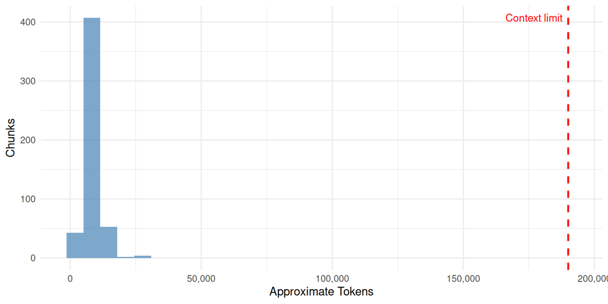

Figure 1: Approximate token count per chunk (C2 input)

```r
ggplot(c2_input, aes(x = approx_tokens)) +
  geom_histogram(bins = 30, fill = "steelblue", alpha = 0.7) +
  geom_vline(xintercept = effective_limit, color = "red",
             linetype = "dashed", linewidth = 0.8) +
  annotate("text", x = effective_limit, y = Inf,
           label = "Context limit", hjust = 1.1, vjust = 2,
           color = "red", size = 3.5) +
  scale_x_continuous(labels = comma) +
  labs(x = "Approximate Tokens", y = "Chunks") +
  theme_minimal()
```

**Test 8**: PASS

## Per-Act Summary

```r
classified_summary <- c1_classified |>
  group_by(act_name) |>
  summarise(
    n_total = n(),
    n_fiscal = sum(pred_label == "FISCAL_MEASURE", na.rm = TRUE),
    .groups = "drop"
  )

c2_summary <- c2_input |>
  count(act_name, name = "n_c2")

per_act <- aligned_data |>
  distinct(act_name, year, motivation_category) |>
  left_join(classified_summary, by = "act_name") |>
  left_join(c2_summary, by = "act_name") |>
  mutate(
    n_total = replace_na(n_total, 0L),
    n_fiscal = replace_na(n_fiscal, 0L),
    n_c2 = replace_na(n_c2, 0L)
  ) |>
  arrange(desc(n_c2))

per_act |>
  gt() |>
  cols_label(
    act_name = "Act",
    year = "Year",
    motivation_category = "Category",
    n_total = "Classified",
    n_fiscal = "FISCAL_MEASURE",
    n_c2 = "C2 Input"
  ) |>
  gt_theme_report()
```

Table 6: Per-act chunk summary: classified vs C2 input

| Act | Year | Category | Classified | FISCAL_MEASURE | C2 Input |
| --- | --- | --- | --- | --- | --- |
| Tax Reform Act of 1969 | 1969 | Countercyclical | 27 | 25 | 24 |
| Expiration of Excess Profits Tax and of Temporary Income Tax Increases | 1954 | Spending-driven | 24 | 21 | 20 |
| Revenue Act of 1964 | 1964 | Long-run | 24 | 24 | 20 |
| Revenue Act of 1978 | 1978 | Long-run | 24 | 21 | 20 |
| Tax Adjustment Act of 1966 | 1966 | Long-run | 22 | 20 | 19 |
| Tax Reform Act of 1986 | 1986 | Long-run | 20 | 19 | 19 |
| Omnibus Budget Reconciliation Act of 1987 | 1987 | Deficit-driven | 22 | 19 | 18 |
| Revenue Act of 1971 | 1971 | Long-run | 23 | 21 | 18 |
| Revenue and Expenditure Control Act of 1968 | 1968 | Countercyclical | 22 | 20 | 18 |
| Social Security Amendments of 1977 | 1977 | Deficit-driven | 21 | 19 | 17 |
| Tax Reduction Act of 1975 | 1975 | Countercyclical | 23 | 21 | 17 |
| Economic Recovery Tax Act of 1981 | 1981 | Long-run | 23 | 17 | 16 |
| Taxpayer Relief Act of 1997 and Balanced Budget Act of 1997 | 1997 | Spending-driven | 21 | 16 | 16 |
| Deficit Reduction Act of 1984 | 1984 | Deficit-driven | 25 | 21 | 15 |
| Job Creation and Worker Assistance Act of 2002 | 2002 | Countercyclical | 22 | 17 | 15 |
| Jobs and Growth Tax Relief Reconciliation Act of 2003 | 2003 | Long-run | 21 | 20 | 14 |
| Public Law 89-800 (Suspension of Investment Tax Credit) | 1966 | Countercyclical | 14 | 14 | 14 |
| Public Law 90-26 (Restoration of the Investment Tax Credit) | 1967 | Long-run | 14 | 14 | 14 |
| Revenue Act of 1948 | 1948 | Long-run | 21 | 20 | 14 |
| Tax Equity and Fiscal Responsibility Act of 1982 | 1982 | Deficit-driven | 20 | 16 | 14 |
| Excise Tax Reduction Act of 1965 | 1965 | Long-run | 21 | 15 | 13 |
| Omnibus Budget Reconciliation Act of 1993 | 1993 | Deficit-driven | 20 | 15 | 13 |
| Tax Reduction and Simplification Act of 1977 | 1977 | Long-run | 21 | 17 | 13 |
| Revenue Act of 1950 | 1950 | Spending-driven | 21 | 16 | 12 |
| Tax Reform Act of 1976 | 1976 | Long-run | 21 | 13 | 12 |
| Changes in Depreciation Guidelines and Revenue Act of 1962 | 1962 | Long-run | 22 | 15 | 11 |
| Economic Growth and Tax Relief Reconciliation Act of 2001 | 2001 | Countercyclical | 20 | 15 | 11 |
| Excise Tax Reduction Act of 1954 | 1954 | Spending-driven | 17 | 15 | 11 |
| Revenue Act of 1945 | 1945 | Spending-driven | 25 | 15 | 11 |
| Social Security Amendments of 1965 | 1965 | Spending-driven | 13 | 11 | 11 |
| Omnibus Budget Reconciliation Act of 1990 | 1990 | Deficit-driven | 20 | 11 | 9 |
| Social Security Amendments of 1983 | 1983 | Deficit-driven | 20 | 13 | 9 |
| Crude Oil Windfall Profit Tax Act of 1980 | 1980 | Long-run | 22 | 15 | 7 |
| Excess Profits Tax Act of 1950 | 1951 | Spending-driven | 22 | 12 | 7 |
| Federal-Aid Highway Act of 1956 | 1956 | Spending-driven | 21 | 8 | 7 |
| Federal-Aid Highway Act of 1959 | 1959 | Deficit-driven | 5 | 5 | 4 |
| Social Security Amendments of 1954 | 1954 | Spending-driven | 6 | 4 | 3 |
| Tax Rate Extension Act of 1958 | 1958 | Long-run | 5 | 4 | 2 |
| Social Security Amendments of 1950 | 1950 | Spending-driven | 8 | 2 | 1 |

## Summary Dashboard

```r
dashboard <- test_results |>
  mutate(test_label = sprintf("T%d: %s", test_id, test_name)) |>
  select(test_label, result, status)

n_pass <- sum(dashboard$status == "PASS")
n_warn <- sum(dashboard$status == "WARN")
n_fail <- sum(dashboard$status == "FAIL")

dashboard |>
  gt() |>
  cols_label(
    test_label = "Test",
    result = "Result",
    status = "Status"
  ) |>
  tab_style(
    style = cell_fill(color = "#ccffcc"),
    locations = cells_body(columns = status, rows = status == "PASS")
  ) |>
  tab_style(
    style = cell_fill(color = "#fff3cd"),
    locations = cells_body(columns = status, rows = status == "WARN")
  ) |>
  tab_style(
    style = cell_fill(color = "#ffcccc"),
    locations = cells_body(columns = status, rows = status == "FAIL")
  ) |>
  gt_theme_report()
```

Table 7: C2 input verification dashboard

| Test | Result | Status |
| --- | --- | --- |
| T1: Act coverage | 39/39 acts present | PASS |
| T2: Label completeness | motivation: 0 NA, exogenous: 0 NA | PASS |
| T3: Text join completeness | 0 NA, 0 empty (of 763 rows) | PASS |
| T4: C1 output fields | pred_label: 0 NA; discusses_motivation: 509 TRUE / 97 FALSE / 157 NA | PASS |
| T5: Filter correctness | Non-FISCAL_MEASURE: 0, discusses_motivation != TRUE: 0 | PASS |
| T6: Act coverage post-filter | 39/39 acts retained (0 lost) | PASS |
| T7: Motivation class balance | 4/4 categories match aligned_data | PASS |
| T8: Token budget fit | Max: 25,870 tokens (limit: 190,000) | PASS |

**Overall**: 8 PASS, 0 WARN, 0 FAIL out of 8 tests.

**All clear:** C1→C2 handoff validated. Data is ready for C2 codebook development.